# Lesson 3: Group-by and Visualization

```r
library(tidyverse)
library(magrittr)
```

# Recap

In the last lesson, we have gone through five functions introduced by the `dplyr` package.

- `select()`
- `filter()`
- `arrange()`
- `mutate()`
- `summarize()`

Load the dataset we created from the last lesson.

```r
df <- read_csv("../data/merged_df.csv")
```

Let’s further examine the difference between `mutate()` and `summarize()`. From the loaded dataframe, calculate the average temperature using the two methods. Can you tell the difference?

```r
df %>%
  mutate(., m = mean(temp)) %>%
  select(., MRN, temp, m)
```

| MRN | temp | m |
| --- | --- | --- |
| DH1301 | 99.18 | 98.53811 |
| DH1301 | 98.96 | 98.53811 |
| DH1301 | 99.29 | 98.53811 |
| DH1301 | 98.63 | 98.53811 |
| DH1301 | 98.57 | 98.53811 |
| DH1301 | 98.25 | 98.53811 |
| DH1301 | 98.47 | 98.53811 |
| DH1301 | 97.53 | 98.53811 |
| DH1301 | 99.44 | 98.53811 |
| DH1301 | 98.01 | 98.53811 |

[output cut: 540 more lines]

```r
df %>%
  summarize(., m = mean(temp))
```

| m |
| --- |
| 98.53811 |

# Grouping with `by` Keyword

There is a shortcut to `group_by()` for each method. With the exception of `select()`, the verbs support the `.by` argument, which applies the grouping operation on the corresponding (and only the corresponding) verb.

For example, let’s say that you want to calculate the average temperature for each patient measured through the experiment. Normally you’d write something like the following.

```r
df %>%
  group_by(., MRN) %>%
  summarize(., m = mean(temp))
```

| MRN | m |
| --- | --- |
| CI6950 | 98.52786 |
| CL3204 | 98.70000 |
| CQ9338 | 98.41333 |
| CQ9671 | 98.43667 |
| CT4319 | 98.15571 |
| DH1301 | 98.55929 |
| EG7985 | 98.76176 |
| FV7418 | 98.60056 |
| GC4075 | 98.36909 |
| GE5166 | 98.71083 |

[output cut: 40 more lines]

Instead, you can simplify this operation as follows.

```r
df %>%
  summarize(., m = mean(temp), .by = MRN)
```

| MRN | m |
| --- | --- |
| DH1301 | 98.55929 |
| JV9469 | 98.77273 |
| TH8119 | 98.57200 |
| TJ3799 | 98.50700 |
| HP1319 | 98.04154 |
| KR5834 | 98.56667 |
| SB7712 | 98.31727 |
| RF5541 | 98.55375 |
| HJ8458 | 98.47857 |
| TG7671 | 98.23167 |

[output cut: 40 more lines]

## Example

Let’s say that we would like to compare each temperature record to the maximum temperature record for each patient. Using the `by =` argument, write a function, in one line, that calculates the maximum temperature for each patient over the course of the experiment. Then add another line that selects `MRN`, `contact_date`, `temp` and the newly created column as the output.

```r
df %>%
  mutate(., m = max(temp), .by = MRN) %>%
  select(., MRN, contact_date, temp, m)
```

| MRN | contact_date | temp | m |
| --- | --- | --- | --- |
| DH1301 | 2018-03-24 | 99.18 | 99.44 |
| DH1301 | 2016-11-03 | 98.96 | 99.44 |
| DH1301 | 2014-07-19 | 99.29 | 99.44 |
| DH1301 | 2019-08-13 | 98.63 | 99.44 |
| DH1301 | 2015-04-02 | 98.57 | 99.44 |
| DH1301 | 2018-10-19 | 98.25 | 99.44 |
| DH1301 | 2016-12-24 | 98.47 | 99.44 |
| DH1301 | 2015-05-01 | 97.53 | 99.44 |
| DH1301 | 2014-08-04 | 99.44 | 99.44 |
| DH1301 | 2019-07-29 | 98.01 | 99.44 |

[output cut: 540 more lines]

# Visualization with `ggplot2`

Plotting with `ggplot2` consists of defining the base layer with the `ggplot()` function, adding layers of *geometries*, or `geoms`, and appending figure information such as axis labels, title, fonts, and so on.

There are multiple types of geometries supported by `ggplot2`. The most widely used geometries are as follows. For example,

- Histograms (`geom_histogram()`)
- Bar charts (`geom_bar()`)
- Scatter Points (`geom_point()`)
- Lines (`geom_line()`)
- Trends (`geom_smooth()`)

Let’s try to visualize our data. First, define the *canvas* by mapping our dataset.

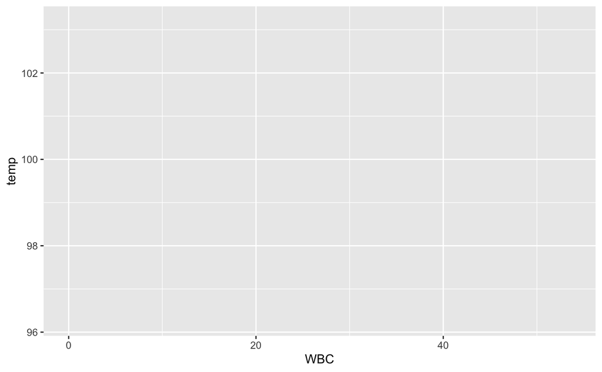

```r
ggplot(data = df, mapping = aes(WBC, temp))
```

Look at the x and y axis. The figure has been defined according to the data ranges in the x and y axis based on the mapping. To add the actual data points, we can then add the geometries as necessary.

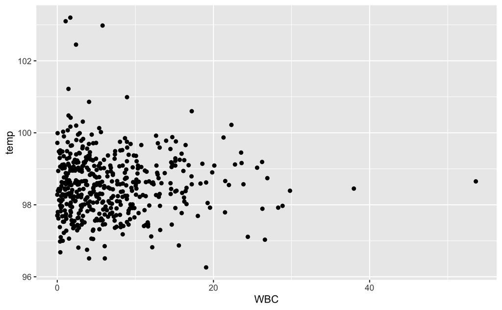

```r
ggplot(df, aes(WBC, temp)) +
  geom_point()
```

We can clean up the rows containing `NA` values. Furthermore, let’s group the points by `race`.

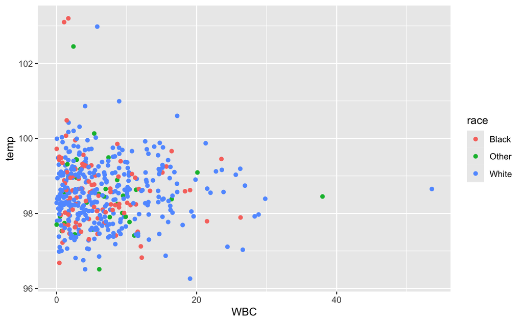

```r
df %>%
  drop_na(.) %>%
  ggplot(., aes(WBC, temp)) +
    geom_point(aes(color = race))
```

A good figure should always have proper axis labels and a title. The labels in `ggplot2` can be written using the `labs()` function.

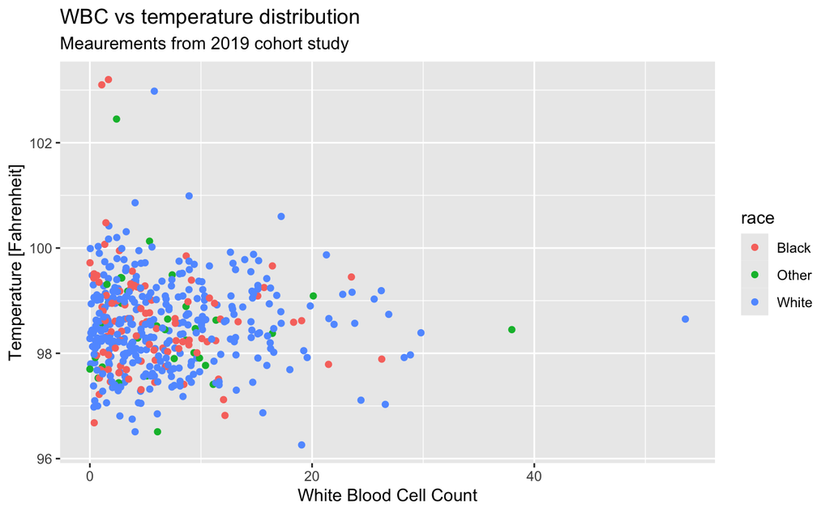

```r
df %>%
  drop_na(.) %>%
  ggplot(., aes(WBC, temp)) +
    geom_point(aes(color = race)) +
    labs(
      title = "WBC vs temperature distribution",
      subtitle = "Meaurements from 2019 cohort study",
      x = "White Blood Cell Count",
      y = "Temperature [Fahrenheit]"
    )
```

## Exercise

Let’s use `palmerpenguins::penguins` dataset. This library contains size measurements of different adult penguin species near Palmer Station, Antarctica, made available by Dr. Kristen Gorman and the Palmer Station, Antarctica LTER.

```r
library(palmerpenguins)
```

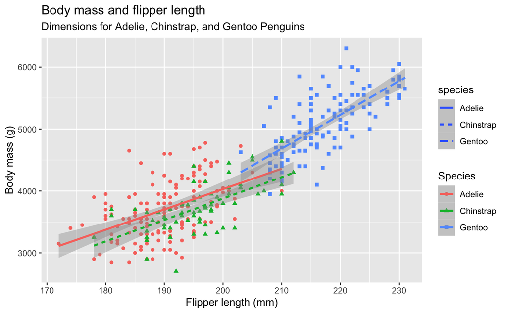